# Risk Factor Analysis

## Outcome Variable

**Outcome Variable:** y_rate_len

## Predictor Variables

**Intervention Variable:** nchldlt5

**Adjustment Set:**

- arm
- W_mage
- meducyrs
- feducyrs
- hhwealth_quart
- hfoodsec
- W_mhtcm
- W_nrooms
- W_parity
- impfloor
- impsan
- safeh20
- delta_W_mage
- delta_meducyrs
- delta_feducyrs
- delta_hhwealth_quart
- delta_hfoodsec
- delta_W_mhtcm
- delta_W_nrooms
- delta_W_parity
- delta_impfloor
- delta_impsan
- delta_safeh20

## Stratifying Variables

The analysis was stratified on these variable(s):

- agecat
- studyid
- country

## Data Summary

| agecat | studyid | country | nchldlt5 | n_cell | n |
| --- | --- | --- | --- | --- | --- |
| 0-3 months | ki1000108-IRC | INDIA | 1 | 82 | 268 |
| 0-3 months | ki1000108-IRC | INDIA | 2+ | 186 | 268 |
| 0-3 months | ki1017093b-PROVIDE | BANGLADESH | 1 | 467 | 476 |
| 0-3 months | ki1017093b-PROVIDE | BANGLADESH | 2+ | 9 | 476 |
| 0-3 months | ki1017093c-NIH-Crypto | BANGLADESH | 1 | 511 | 517 |
| 0-3 months | ki1017093c-NIH-Crypto | BANGLADESH | 2+ | 6 | 517 |
| 0-3 months | kiGH5241-JiVitA-3 | BANGLADESH | 1 | 24944 | 25864 |
| 0-3 months | kiGH5241-JiVitA-3 | BANGLADESH | 2+ | 920 | 25864 |
| 3-6 months | ki1000108-IRC | INDIA | 1 | 87 | 283 |
| 3-6 months | ki1000108-IRC | INDIA | 2+ | 196 | 283 |
| 3-6 months | ki1017093b-PROVIDE | BANGLADESH | 1 | 421 | 429 |
| 3-6 months | ki1017093b-PROVIDE | BANGLADESH | 2+ | 8 | 429 |
| 3-6 months | ki1017093c-NIH-Crypto | BANGLADESH | 1 | 492 | 497 |
| 3-6 months | ki1017093c-NIH-Crypto | BANGLADESH | 2+ | 5 | 497 |
| 3-6 months | ki1066203-TanzaniaChild2 | TANZANIA, UNITED REPUBLIC OF | 1 | 1145 | 1194 |
| 3-6 months | ki1066203-TanzaniaChild2 | TANZANIA, UNITED REPUBLIC OF | 2+ | 49 | 1194 |
| 3-6 months | kiGH5241-JiVitA-3 | BANGLADESH | 1 | 16204 | 16720 |
| 3-6 months | kiGH5241-JiVitA-3 | BANGLADESH | 2+ | 516 | 16720 |
| 6-12 months | ki1000108-IRC | INDIA | 1 | 88 | 284 |
| 6-12 months | ki1000108-IRC | INDIA | 2+ | 196 | 284 |
| 6-12 months | ki1017093b-PROVIDE | BANGLADESH | 1 | 399 | 407 |
| 6-12 months | ki1017093b-PROVIDE | BANGLADESH | 2+ | 8 | 407 |
| 6-12 months | ki1017093c-NIH-Crypto | BANGLADESH | 1 | 474 | 478 |
| 6-12 months | ki1017093c-NIH-Crypto | BANGLADESH | 2+ | 4 | 478 |
| 6-12 months | ki1066203-TanzaniaChild2 | TANZANIA, UNITED REPUBLIC OF | 1 | 769 | 798 |
| 6-12 months | ki1066203-TanzaniaChild2 | TANZANIA, UNITED REPUBLIC OF | 2+ | 29 | 798 |
| 6-12 months | ki1148112-LCNI-5 | MALAWI | 1 | 205 | 233 |
| 6-12 months | ki1148112-LCNI-5 | MALAWI | 2+ | 28 | 233 |
| 6-12 months | kiGH5241-JiVitA-3 | BANGLADESH | 1 | 12583 | 12993 |
| 6-12 months | kiGH5241-JiVitA-3 | BANGLADESH | 2+ | 410 | 12993 |
| 12-24 months | ki1000108-IRC | INDIA | 1 | 86 | 280 |
| 12-24 months | ki1000108-IRC | INDIA | 2+ | 194 | 280 |
| 12-24 months | ki1017093b-PROVIDE | BANGLADESH | 1 | 331 | 337 |
| 12-24 months | ki1017093b-PROVIDE | BANGLADESH | 2+ | 6 | 337 |
| 12-24 months | ki1017093c-NIH-Crypto | BANGLADESH | 1 | 341 | 344 |
| 12-24 months | ki1017093c-NIH-Crypto | BANGLADESH | 2+ | 3 | 344 |
| 12-24 months | ki1066203-TanzaniaChild2 | TANZANIA, UNITED REPUBLIC OF | 1 | 1 | 1 |
| 12-24 months | ki1066203-TanzaniaChild2 | TANZANIA, UNITED REPUBLIC OF | 2+ | 0 | 1 |
| 12-24 months | ki1148112-LCNI-5 | MALAWI | 1 | 152 | 171 |
| 12-24 months | ki1148112-LCNI-5 | MALAWI | 2+ | 19 | 171 |
| 12-24 months | kiGH5241-JiVitA-3 | BANGLADESH | 1 | 5807 | 6033 |
| 12-24 months | kiGH5241-JiVitA-3 | BANGLADESH | 2+ | 226 | 6033 |

The following strata were considered:

- agecat: 0-3 months, studyid: ki1000108-IRC, country: INDIA
- agecat: 0-3 months, studyid: ki1017093b-PROVIDE, country: BANGLADESH
- agecat: 0-3 months, studyid: ki1017093c-NIH-Crypto, country: BANGLADESH
- agecat: 0-3 months, studyid: kiGH5241-JiVitA-3, country: BANGLADESH
- agecat: 12-24 months, studyid: ki1000108-IRC, country: INDIA
- agecat: 12-24 months, studyid: ki1017093b-PROVIDE, country: BANGLADESH
- agecat: 12-24 months, studyid: ki1017093c-NIH-Crypto, country: BANGLADESH
- agecat: 12-24 months, studyid: ki1066203-TanzaniaChild2, country: TANZANIA, UNITED REPUBLIC OF
- agecat: 12-24 months, studyid: ki1148112-LCNI-5, country: MALAWI
- agecat: 12-24 months, studyid: kiGH5241-JiVitA-3, country: BANGLADESH
- agecat: 3-6 months, studyid: ki1000108-IRC, country: INDIA
- agecat: 3-6 months, studyid: ki1017093b-PROVIDE, country: BANGLADESH
- agecat: 3-6 months, studyid: ki1017093c-NIH-Crypto, country: BANGLADESH
- agecat: 3-6 months, studyid: ki1066203-TanzaniaChild2, country: TANZANIA, UNITED REPUBLIC OF
- agecat: 3-6 months, studyid: kiGH5241-JiVitA-3, country: BANGLADESH
- agecat: 6-12 months, studyid: ki1000108-IRC, country: INDIA
- agecat: 6-12 months, studyid: ki1017093b-PROVIDE, country: BANGLADESH
- agecat: 6-12 months, studyid: ki1017093c-NIH-Crypto, country: BANGLADESH
- agecat: 6-12 months, studyid: ki1066203-TanzaniaChild2, country: TANZANIA, UNITED REPUBLIC OF
- agecat: 6-12 months, studyid: ki1148112-LCNI-5, country: MALAWI
- agecat: 6-12 months, studyid: kiGH5241-JiVitA-3, country: BANGLADESH

### Dropped Strata

Some strata were dropped due to rare outcomes:

- agecat: 6-12 months, studyid: ki1017093c-NIH-Crypto, country: BANGLADESH
- agecat: 12-24 months, studyid: ki1017093c-NIH-Crypto, country: BANGLADESH
- agecat: 12-24 months, studyid: ki1066203-TanzaniaChild2, country: TANZANIA, UNITED REPUBLIC OF

## Methods Detail

We’re interested in the causal parameters $E[Y_a]$ for all values of $a \in \mathcal{A}$. These parameters represent the mean outcome if, possibly contrary to fact, we intervened to set all units to have $A=a$. Under the randomization and positivity assumptions, these are identified by the statistical parameters $\psi_a=E_W[E_{Y|A,W}(Y|A=a,W)]$. In addition, we’re interested in the mean of $Y$, $E[Y]$ under no intervention (the observed mean). We will estimate these parameters by using SuperLearner to fit the relevant likelihood factors – $E_{Y|A,W}(Y|A=a,W)$ and $p(A=a|W)$, and then updating our likelihood fit using a joint TMLE.

For unadjusted analyses ($W=\{\}$), initial likelihoods were estimated using Lrnr_glm to estimate the simple $E(Y|A)$ and Lrnr_mean to estimate $p(A)$. For adjusted analyses, a small library containing Lrnr_glmnet, Lrnr_xgboost, and Lrnr_mean was used.

Having estimated these parameters, we will then use the delta method to estimate relative risks and attributable risks relative to a prespecified baseline level of $A$.

# Results Detail

## Results Plots

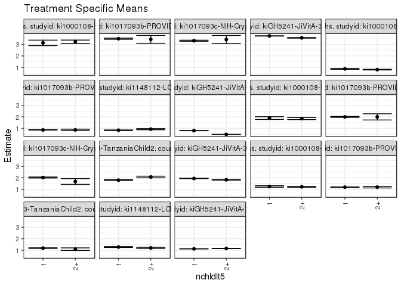

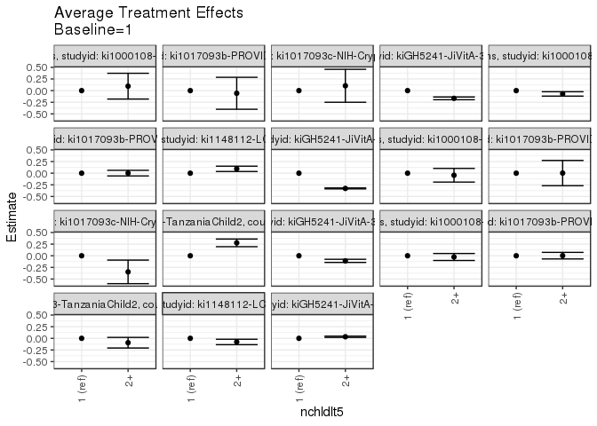

## Results Table

### Parameter: TSM

| agecat | studyid | country | intervention_level | baseline_level | estimate | ci_lower | ci_upper |
| --- | --- | --- | --- | --- | --- | --- | --- |
| 0-3 months | ki1000108-IRC | INDIA | 1 | NA | 3.1335222 | 2.8963596 | 3.3706849 |
| 0-3 months | ki1000108-IRC | INDIA | 2+ | NA | 3.2289487 | 3.0825302 | 3.3753672 |
| 0-3 months | ki1017093b-PROVIDE | BANGLADESH | 1 | NA | 3.4953761 | 3.4488272 | 3.5419250 |
| 0-3 months | ki1017093b-PROVIDE | BANGLADESH | 2+ | NA | 3.4381842 | 3.0982465 | 3.7781219 |
| 0-3 months | ki1017093c-NIH-Crypto | BANGLADESH | 1 | NA | 3.3215718 | 3.2751419 | 3.3680018 |
| 0-3 months | ki1017093c-NIH-Crypto | BANGLADESH | 2+ | NA | 3.4254477 | 3.0745761 | 3.7763192 |
| 0-3 months | kiGH5241-JiVitA-3 | BANGLADESH | 1 | NA | 3.7366807 | 3.7249583 | 3.7484031 |
| 0-3 months | kiGH5241-JiVitA-3 | BANGLADESH | 2+ | NA | 3.5705081 | 3.5431714 | 3.5978449 |
| 3-6 months | ki1000108-IRC | INDIA | 1 | NA | 1.8972511 | 1.7781660 | 2.0163362 |
| 3-6 months | ki1000108-IRC | INDIA | 2+ | NA | 1.8527642 | 1.7635164 | 1.9420121 |
| 3-6 months | ki1017093b-PROVIDE | BANGLADESH | 1 | NA | 1.9955268 | 1.9544631 | 2.0365904 |
| 3-6 months | ki1017093b-PROVIDE | BANGLADESH | 2+ | NA | 1.9979433 | 1.7299829 | 2.2659038 |
| 3-6 months | ki1017093c-NIH-Crypto | BANGLADESH | 1 | NA | 2.0255186 | 1.9832512 | 2.0677860 |
| 3-6 months | ki1017093c-NIH-Crypto | BANGLADESH | 2+ | NA | 1.6790308 | 1.4291004 | 1.9289613 |
| 3-6 months | ki1066203-TanzaniaChild2 | TANZANIA, UNITED REPUBLIC OF | 1 | NA | 1.7945658 | 1.7508174 | 1.8383141 |
| 3-6 months | ki1066203-TanzaniaChild2 | TANZANIA, UNITED REPUBLIC OF | 2+ | NA | 2.0714208 | 1.9999336 | 2.1429080 |
| 3-6 months | kiGH5241-JiVitA-3 | BANGLADESH | 1 | NA | 1.9416427 | 1.9288780 | 1.9544073 |
| 3-6 months | kiGH5241-JiVitA-3 | BANGLADESH | 2+ | NA | 1.8319388 | 1.8015652 | 1.8623123 |
| 6-12 months | ki1000108-IRC | INDIA | 1 | NA | 1.2470548 | 1.1819520 | 1.3121576 |
| 6-12 months | ki1000108-IRC | INDIA | 2+ | NA | 1.2205587 | 1.1827838 | 1.2583336 |
| 6-12 months | ki1017093b-PROVIDE | BANGLADESH | 1 | NA | 1.1864243 | 1.1661662 | 1.2066824 |
| 6-12 months | ki1017093b-PROVIDE | BANGLADESH | 2+ | NA | 1.1886993 | 1.1209123 | 1.2564863 |
| 6-12 months | ki1066203-TanzaniaChild2 | TANZANIA, UNITED REPUBLIC OF | 1 | NA | 1.1890625 | 1.1639229 | 1.2142021 |
| 6-12 months | ki1066203-TanzaniaChild2 | TANZANIA, UNITED REPUBLIC OF | 2+ | NA | 1.0951056 | 0.9833267 | 1.2068844 |
| 6-12 months | ki1148112-LCNI-5 | MALAWI | 1 | NA | 1.2815430 | 1.2437611 | 1.3193249 |
| 6-12 months | ki1148112-LCNI-5 | MALAWI | 2+ | NA | 1.2040725 | 1.1528815 | 1.2552636 |
| 6-12 months | kiGH5241-JiVitA-3 | BANGLADESH | 1 | NA | 1.1272101 | 1.1191804 | 1.1352397 |
| 6-12 months | kiGH5241-JiVitA-3 | BANGLADESH | 2+ | NA | 1.1607468 | 1.1506315 | 1.1708621 |
| 12-24 months | ki1000108-IRC | INDIA | 1 | NA | 0.8771970 | 0.8371315 | 0.9172625 |
| 12-24 months | ki1000108-IRC | INDIA | 2+ | NA | 0.8062917 | 0.7798477 | 0.8327357 |
| 12-24 months | ki1017093b-PROVIDE | BANGLADESH | 1 | NA | 0.8657367 | 0.8512370 | 0.8802363 |
| 12-24 months | ki1017093b-PROVIDE | BANGLADESH | 2+ | NA | 0.8672424 | 0.8084294 | 0.9260554 |
| 12-24 months | ki1148112-LCNI-5 | MALAWI | 1 | NA | 0.8377675 | 0.8133282 | 0.8622068 |
| 12-24 months | ki1148112-LCNI-5 | MALAWI | 2+ | NA | 0.9316275 | 0.8800848 | 0.9831703 |
| 12-24 months | kiGH5241-JiVitA-3 | BANGLADESH | 1 | NA | 0.8054651 | 0.7989490 | 0.8119812 |
| 12-24 months | kiGH5241-JiVitA-3 | BANGLADESH | 2+ | NA | 0.4780177 | 0.4704780 | 0.4855573 |

### Parameter: E(Y)

| agecat | studyid | country | intervention_level | baseline_level | estimate | ci_lower | ci_upper |
| --- | --- | --- | --- | --- | --- | --- | --- |
| 0-3 months | ki1000108-IRC | INDIA | NA | NA | 3.2019764 | 3.0666007 | 3.3373520 |
| 0-3 months | ki1017093b-PROVIDE | BANGLADESH | NA | NA | 3.4942947 | 3.4481705 | 3.5404189 |
| 0-3 months | ki1017093c-NIH-Crypto | BANGLADESH | NA | NA | 3.3227773 | 3.2766959 | 3.3688588 |
| 0-3 months | kiGH5241-JiVitA-3 | BANGLADESH | NA | NA | 3.7346404 | 3.7229050 | 3.7463757 |
| 3-6 months | ki1000108-IRC | INDIA | NA | NA | 1.8672579 | 1.7900624 | 1.9444533 |
| 3-6 months | ki1017093b-PROVIDE | BANGLADESH | NA | NA | 1.9955718 | 1.9549653 | 2.0361784 |
| 3-6 months | ki1017093c-NIH-Crypto | BANGLADESH | NA | NA | 2.0220328 | 1.9800048 | 2.0640608 |
| 3-6 months | ki1066203-TanzaniaChild2 | TANZANIA, UNITED REPUBLIC OF | NA | NA | 1.8042528 | 1.7611654 | 1.8473402 |
| 3-6 months | kiGH5241-JiVitA-3 | BANGLADESH | NA | NA | 1.9374947 | 1.9250089 | 1.9499805 |
| 6-12 months | ki1000108-IRC | INDIA | NA | NA | 1.2312615 | 1.1963858 | 1.2661373 |
| 6-12 months | ki1017093b-PROVIDE | BANGLADESH | NA | NA | 1.1864690 | 1.1665645 | 1.2063735 |
| 6-12 months | ki1066203-TanzaniaChild2 | TANZANIA, UNITED REPUBLIC OF | NA | NA | 1.1856107 | 1.1608382 | 1.2103832 |
| 6-12 months | ki1148112-LCNI-5 | MALAWI | NA | NA | 1.2810310 | 1.2456500 | 1.3164121 |
| 6-12 months | kiGH5241-JiVitA-3 | BANGLADESH | NA | NA | 1.1237755 | 1.1157915 | 1.1317595 |
| 12-24 months | ki1000108-IRC | INDIA | NA | NA | 0.8255144 | 0.8011582 | 0.8498706 |
| 12-24 months | ki1017093b-PROVIDE | BANGLADESH | NA | NA | 0.8657635 | 0.8514835 | 0.8800435 |
| 12-24 months | ki1148112-LCNI-5 | MALAWI | NA | NA | 0.8389657 | 0.8160911 | 0.8618403 |
| 12-24 months | kiGH5241-JiVitA-3 | BANGLADESH | NA | NA | 0.8037876 | 0.7972112 | 0.8103640 |

### Parameter: ATE

| agecat | studyid | country | intervention_level | baseline_level | estimate | ci_lower | ci_upper |
| --- | --- | --- | --- | --- | --- | --- | --- |
| 0-3 months | ki1000108-IRC | INDIA | 1 | 1 | 0.0000000 | 0.0000000 | 0.0000000 |
| 0-3 months | ki1000108-IRC | INDIA | 2+ | 1 | 0.0954264 | -0.1811286 | 0.3719814 |
| 0-3 months | ki1017093b-PROVIDE | BANGLADESH | 1 | 1 | 0.0000000 | 0.0000000 | 0.0000000 |
| 0-3 months | ki1017093b-PROVIDE | BANGLADESH | 2+ | 1 | -0.0571919 | -0.4003019 | 0.2859180 |
| 0-3 months | ki1017093c-NIH-Crypto | BANGLADESH | 1 | 1 | 0.0000000 | 0.0000000 | 0.0000000 |
| 0-3 months | ki1017093c-NIH-Crypto | BANGLADESH | 2+ | 1 | 0.1038758 | -0.2500543 | 0.4578060 |
| 0-3 months | kiGH5241-JiVitA-3 | BANGLADESH | 1 | 1 | 0.0000000 | 0.0000000 | 0.0000000 |
| 0-3 months | kiGH5241-JiVitA-3 | BANGLADESH | 2+ | 1 | -0.1661726 | -0.1955867 | -0.1367584 |
| 3-6 months | ki1000108-IRC | INDIA | 1 | 1 | 0.0000000 | 0.0000000 | 0.0000000 |
| 3-6 months | ki1000108-IRC | INDIA | 2+ | 1 | -0.0444869 | -0.1914675 | 0.1024938 |
| 3-6 months | ki1017093b-PROVIDE | BANGLADESH | 1 | 1 | 0.0000000 | 0.0000000 | 0.0000000 |
| 3-6 months | ki1017093b-PROVIDE | BANGLADESH | 2+ | 1 | 0.0024166 | -0.2686720 | 0.2735052 |
| 3-6 months | ki1017093c-NIH-Crypto | BANGLADESH | 1 | 1 | 0.0000000 | 0.0000000 | 0.0000000 |
| 3-6 months | ki1017093c-NIH-Crypto | BANGLADESH | 2+ | 1 | -0.3464878 | -0.5999671 | -0.0930085 |
| 3-6 months | ki1066203-TanzaniaChild2 | TANZANIA, UNITED REPUBLIC OF | 1 | 1 | 0.0000000 | 0.0000000 | 0.0000000 |
| 3-6 months | ki1066203-TanzaniaChild2 | TANZANIA, UNITED REPUBLIC OF | 2+ | 1 | 0.2768550 | 0.1946552 | 0.3590549 |
| 3-6 months | kiGH5241-JiVitA-3 | BANGLADESH | 1 | 1 | 0.0000000 | 0.0000000 | 0.0000000 |
| 3-6 months | kiGH5241-JiVitA-3 | BANGLADESH | 2+ | 1 | -0.1097039 | -0.1437108 | -0.0756971 |
| 6-12 months | ki1000108-IRC | INDIA | 1 | 1 | 0.0000000 | 0.0000000 | 0.0000000 |
| 6-12 months | ki1000108-IRC | INDIA | 2+ | 1 | -0.0264961 | -0.1016977 | 0.0487055 |
| 6-12 months | ki1017093b-PROVIDE | BANGLADESH | 1 | 1 | 0.0000000 | 0.0000000 | 0.0000000 |
| 6-12 months | ki1017093b-PROVIDE | BANGLADESH | 2+ | 1 | 0.0022750 | -0.0684743 | 0.0730243 |
| 6-12 months | ki1066203-TanzaniaChild2 | TANZANIA, UNITED REPUBLIC OF | 1 | 1 | 0.0000000 | 0.0000000 | 0.0000000 |
| 6-12 months | ki1066203-TanzaniaChild2 | TANZANIA, UNITED REPUBLIC OF | 2+ | 1 | -0.0939569 | -0.2080108 | 0.0200969 |
| 6-12 months | ki1148112-LCNI-5 | MALAWI | 1 | 1 | 0.0000000 | 0.0000000 | 0.0000000 |
| 6-12 months | ki1148112-LCNI-5 | MALAWI | 2+ | 1 | -0.0774705 | -0.1359314 | -0.0190095 |
| 6-12 months | kiGH5241-JiVitA-3 | BANGLADESH | 1 | 1 | 0.0000000 | 0.0000000 | 0.0000000 |
| 6-12 months | kiGH5241-JiVitA-3 | BANGLADESH | 2+ | 1 | 0.0335368 | 0.0205259 | 0.0465476 |
| 12-24 months | ki1000108-IRC | INDIA | 1 | 1 | 0.0000000 | 0.0000000 | 0.0000000 |
| 12-24 months | ki1000108-IRC | INDIA | 2+ | 1 | -0.0709053 | -0.1180447 | -0.0237659 |
| 12-24 months | ki1017093b-PROVIDE | BANGLADESH | 1 | 1 | 0.0000000 | 0.0000000 | 0.0000000 |
| 12-24 months | ki1017093b-PROVIDE | BANGLADESH | 2+ | 1 | 0.0015057 | -0.0590682 | 0.0620797 |
| 12-24 months | ki1148112-LCNI-5 | MALAWI | 1 | 1 | 0.0000000 | 0.0000000 | 0.0000000 |
| 12-24 months | ki1148112-LCNI-5 | MALAWI | 2+ | 1 | 0.0938600 | 0.0366026 | 0.1511175 |
| 12-24 months | kiGH5241-JiVitA-3 | BANGLADESH | 1 | 1 | 0.0000000 | 0.0000000 | 0.0000000 |
| 12-24 months | kiGH5241-JiVitA-3 | BANGLADESH | 2+ | 1 | -0.3274474 | -0.3375333 | -0.3173616 |